# Color Codes for Blackstone

July 09, 2024

# Updated Color Codes and Guidance for Data Visualizations

Updated guidance for colors to be used in all visuals for Blackstone Research and Evaluation

There are three new color palettes, each to be used in specific circumstances:

- The Blue Sequential Color Palette
- The Blue-Red Diverging Color Palette
- The Qualitative Color Palette

The Blue Sequential Color Palette should be used with stacked bar charts that have a likert scale that has one clear direction like: Minimal, Slight, Moderate, Good, Extensive

The Blue-Red Diverging Color Palette should be used with stacked bar charts that have a likert scale that is folded or runs from a negative to positive valence like this: Strongly Disagree, Somewhat Disagree, Disagree, Neither Agree or Disagree, Agree, Somewhat Agree, Strongly Agree

The Qualitative Color Palette should be used for arrow charts with a grouping variable or horizontal bar charts with demographics (this palette may have limited uses at this time).

Below are the full hex color codes for each of the color palettes and examples that use each of color palettes.

Please reach out to Zack Crowley via Google Chat or email if you need hex codes for scales or different lengths than those provided here or if you have any other questions or clarifications about which color palettes to use and data visualizations in general.

## Blue Sequential Color Palette

### Hex Codes for the Blue Sequential Color Palette

#### **5 point scale:**

`#DDDDDD`, `#AEC3DF`, `#7798BF`, `#0466A2`, `#023163`

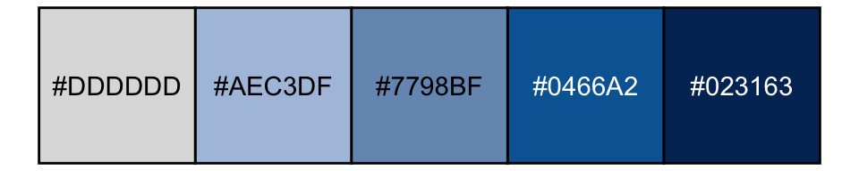

#### **7 point scale:**

`#DDDDDD`, `#BDCFE6`, `#9FB5D5`, `#7798BF`, `#4677A7`, `#00548B`, `#023163`

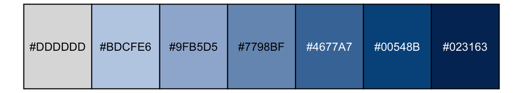

### Example use of the Blue Sequential Color Palette in a Stacked Bar Chart with a 5-point Likert Scale:

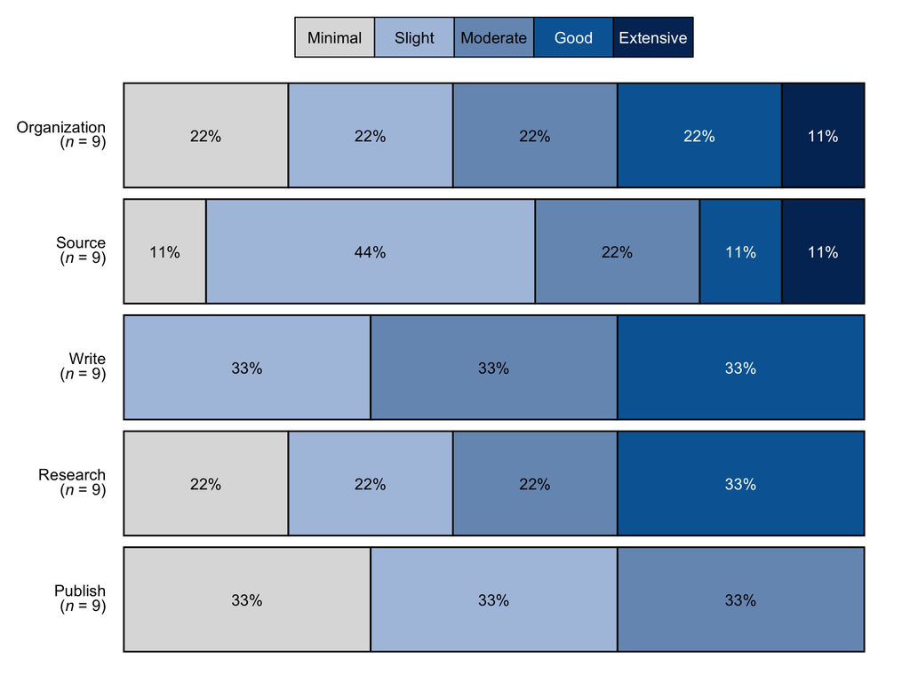

## The Blue-Red Diverging Color Palette

### Hex Codes for the Blue-Red Diverging Color Palette

#### **5 point scale:**

`#600204`, `#B88081`, `#DADADA`, `#7F8EB8`, `#012B67`

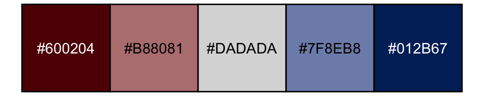

#### **7 point scale:**

`#600204`, `#A25959`, `#CDA2A3`, `#DADADA`, `#A3ADCB`, `#536DA8`, `#012B67`

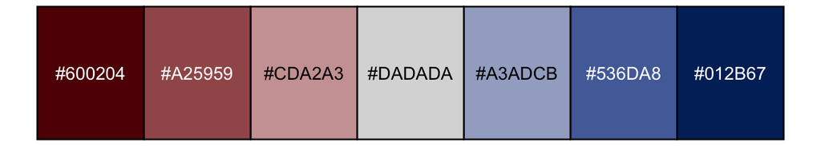

### Example of a Stacked Pre-Post bar chart with The Blue-Red Diverging Color Palette on a 7 point scale:

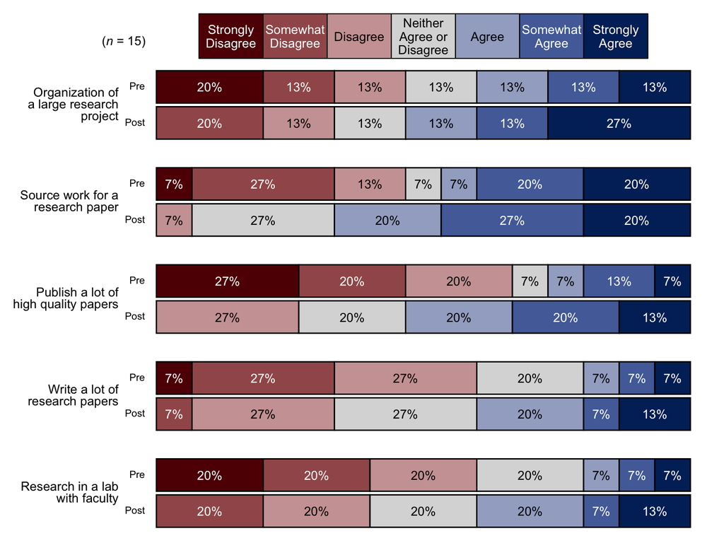

### Main color for arrow charts without groups or table headings

### Blackstone Dark Blue Hex Code #283251

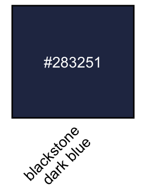

### Arrow chart example without grouping variable:

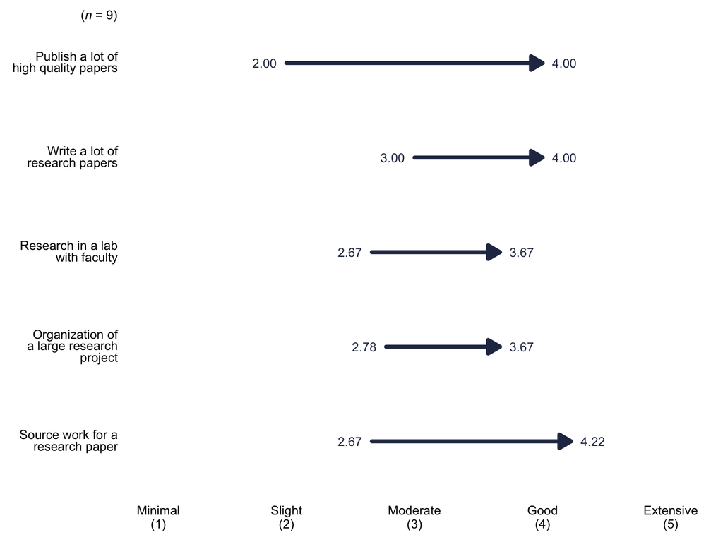

## Qualitative/Categorical Color Palette

The Qualitative Color Palette should be used for arrow charts with a grouping variable or for horizontal bar charts for demographics.

### Hex codes for the Qualitative Color Palette

`#E69F00`, `#56B4E9`, `#009E73`, `#CC79A7`, `#D55E00`, `#0072B2`, `#440154FF`, `#999999`, `#117733`, `#283251`, `#999933`

### Example Swatch of Qualitative Color Palette with names and hex codes:

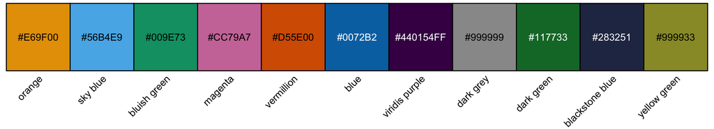

### Example of an Arrow chart with Grouping Variable and the Qualitative Color Palette:

#### - The “Overall” group will always be the color black

#### - This also shows what left/negative direction arrows would look like with the `Research` items.

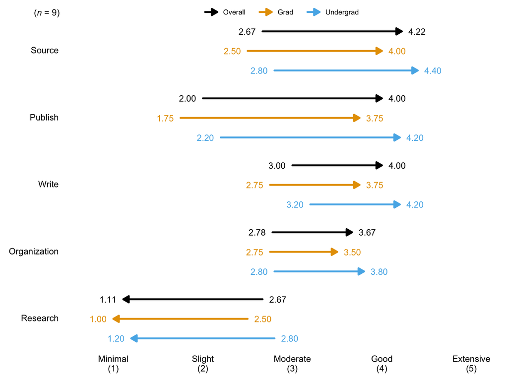

### Example of a Horizontal Bar Chart with Qualitative Color Palette:

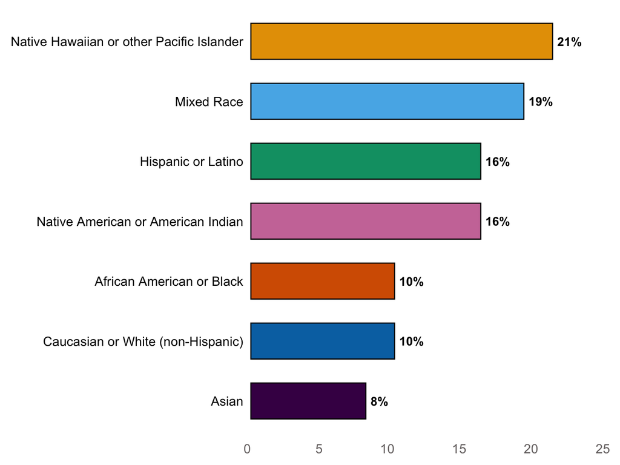